# K-Prototype Clustering

**About Blood Transfusion dataset**  
To demonstrate the RFMTC marketing model (a modified version of RFM), this study adopted the donor database of Blood Transfusion Service Center in Hsin-Chu City in Taiwan. The center passes their blood transfusion service bus to one university in Hsin-Chu City to gather blood donated about every three months. To build a FRMTC model, we selected 748 donors at random from the donor database. These 748 donor data, each one included R (Recency - months since last donation), F (Frequency - total number of donation), M (Monetary - total blood donated in c.c.), T (Time - months since first donation), and a binary variable representing whether he/she donated blood in March 2007 (1 stand for donating blood; 0 stands for not donating blood).

**Attribute Information:**

- R (Recency - months since last donation),
- F (Frequency - total number of donation),
- M (Monetary - total blood donated in c.c.),
- T (Time - months since first donation), and a binary variable representing whether he/she donated blood in March 2007 (1 stand for donating blood; 0 stands for not donating blood).
- Variable Data Type Measurement Description min max mean std
- Recency quantitative Months Input 0.03 74.4 9.74 8.07
- Frequency quantitative Times Input 1 50 5.51 5.84
- Monetary quantitative c.c. blood Input 250 12500 1378.68 1459.83
- Time quantitative Months Input 2.27 98.3 34.42 24.32
- Whether he/she donated blood in March 2007 binary 1=yes 0=no Output 0 1 1 (24%) 0 (76%)

```python
# Importing Libraries
import numpy as np
import pandas as pd
from kmodes.kprototypes import KPrototypes
%matplotlib inline
import matplotlib.pyplot as plt
import seaborn as sns
```

```python
help(KPrototypes)
```

[output not shown]

[output cut: 68 more lines]

[output not shown]

```python
# Reading Dataset
blood = pd.read_csv('https://archive.ics.uci.edu/ml/machine-learning-databases/blood-transfusion/transfusion.data', sep=",",engine = 'python')
```

```python
#Sanity Check
blood.head()
```

|  | Recency (months) | Frequency (times) | Monetary (c.c. blood) | Time (months) | whether he/she donated blood in March 2007 |
| --- | --- | --- | --- | --- | --- |
| 0 | 2 | 50 | 12500 | 98 | 1 |
| 1 | 0 | 13 | 3250 | 28 | 1 |
| 2 | 1 | 16 | 4000 | 35 | 1 |
| 3 | 2 | 20 | 5000 | 45 | 1 |
| 4 | 1 | 24 | 6000 | 77 | 0 |

```python
# standardizing data
columns_to_normalize     = ['Recency (months)','Frequency (times)','Monetary (c.c. blood)','Time (months)']
blood[columns_to_normalize] = blood[columns_to_normalize].apply(lambda x: (x - x.mean()) / np.std(x))
```

```python
# Re-check after standardizing data
blood.head()
```

|  | Recency (months) | Frequency (times) | Monetary (c.c. blood) | Time (months) | whether he/she donated blood in March 2007 |
| --- | --- | --- | --- | --- | --- |
| 0 | -0.927899 | 7.623346 | 7.623346 | 2.615633 | 1 |
| 1 | -1.175118 | 1.282738 | 1.282738 | -0.257881 | 1 |
| 2 | -1.051508 | 1.796842 | 1.796842 | 0.029471 | 1 |
| 3 | -0.927899 | 2.482313 | 2.482313 | 0.439973 | 1 |
| 4 | -1.051508 | 3.167784 | 3.167784 | 1.753579 | 0 |

```python
# Converting the dataset into matrix
blood_matrix = blood.as_matrix()
```

```python
# Martix for analysis
blood_matrix
```

```
array([[-0.92789873,  7.62334626,  7.62334626,  2.61563344,  1.        ],
       [-1.17511806,  1.28273826,  1.28273826, -0.2578809 ,  1.        ],
       [-1.0515084 ,  1.79684161,  1.79684161,  0.02947053,  1.        ],
       ...,
       [ 1.66790417, -0.43093957, -0.43093957,  1.13782607,  0.        ],
       [ 3.64565877, -0.77367514, -0.77367514,  0.19367135,  0.        ],
       [ 7.72477762, -0.77367514, -0.77367514,  1.54832812,  0.        ]])
```

```python
# Running K-Prototype clustering
kproto = KPrototypes(n_clusters=5, init='Cao')
clusters = kproto.fit_predict(blood_matrix, categorical=[4])
```

```python
kproto.cluster_centroids_
```

```
[array([[ 1.20155863, -0.0434147 , -0.0434147 ,  1.16721428],
        [-0.5217527 ,  4.8324995 ,  4.8324995 ,  2.12009883],
        [ 0.77649881, -0.51171646, -0.51171646, -0.41737993],
        [-0.77483521, -0.39947752, -0.39947752, -0.73541024],
        [-0.46834379,  0.94841338,  0.94841338,  0.92401242]]), array([[0.],
        [0.],
        [0.],
        [0.],
        [0.]])]
```

```python
# Checking the cost of the clusters created.
kproto.cost_
```

```
915.5424569187537
```

```python
# Adding the predicted clusters to the main dataset
blood['cluster_id'] = clusters
```

```python
# Re-check
blood.head()
```

[output not shown]

```python
# Checking the clusters created
blooddf = pd.DataFrame(blood['cluster_id'].value_counts())
blooddf
```

|  | cluster_id |
| --- | --- |
| 1 | 267 |
| 0 | 213 |
| 2 | 180 |
| 3 | 80 |
| 4 | 8 |

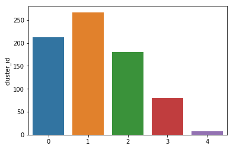

```python
sns.barplot(x=blooddf.index, y=blooddf['cluster_id'])
```

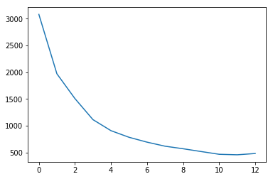

```python
#Choosing optimal K
cost = []
for num_clusters in list(range(1,14)):
    kproto = KPrototypes(n_clusters=num_clusters, init='Cao')
    kproto.fit_predict(blood_matrix, categorical=[4])
    cost.append(kproto.cost_)

plt.plot(cost)
```